# Introduction to Neural Networks: Bank Churn prediction

## Problem Statement

### Context

Businesses like banks which provide service have to worry about problem of 'Customer Churn' i.e. customers leaving and joining another service provider. It is important to understand which aspects of the service influence a customer's decision in this regard. Management can concentrate efforts on improvement of service, keeping in mind these priorities.

### Objective

You as a Data scientist with the bank need to build a neural network based classifier that can determine whether a customer will leave the bank or not in the next 6 months.

### Data Dictionary:

- CustomerId: Unique ID which is assigned to each customer
- Surname: Last name of the customer
- CreditScore: It defines the credit history of the customer.
- Geography: A customer’s location
- Gender: It defines the Gender of the customer
- Age: Age of the customer
- Tenure: Number of years for which the customer has been with the bank
- NumOfProducts: refers to the number of products that a customer has purchased through the bank.
- Balance: Account balance
- HasCrCard: It is a categorical variable which decides whether the customer has credit card or not.
- EstimatedSalary: Estimated salary
- isActiveMember: Is is a categorical variable which decides whether the customer is active member of the bank or not ( Active member in the sense, using bank products regularly, making transactions etc )
- Exited : whether or not the customer left the bank within six month. It can take two values **0=No ( Customer did not leave the bank )** 1=Yes ( Customer left the bank )

## Importing necessary libraries

```python
!pip install scikeras
```

```python
import numpy as np
import pandas as pd
import matplotlib.pyplot as plt
import seaborn as sns
import tensorflow as tf
from tensorflow import keras
from sklearn.model_selection import train_test_split, GridSearchCV, RandomizedSearchCV
from scikeras.wrappers import KerasClassifier
from sklearn.preprocessing import StandardScaler
from imblearn.over_sampling import RandomOverSampler
from keras.models import Sequential
from keras.layers import Dense, Dropout
from keras.optimizers import Adam
from sklearn.metrics import precision_score, recall_score, accuracy_score, f1_score
from sklearn.metrics import make_scorer
from imblearn.over_sampling import SMOTE
from tensorflow.keras.models import Sequential
from tensorflow.keras.layers import Dense, Dropout
```

## Loading the dataset

```python
from google.colab import drive
drive.mount('/content/drive')

df = pd.read_csv('/content/drive/MyDrive/Churn.csv')
```

## Data Overview

```python
df.info()
```

```
<class 'pandas.core.frame.DataFrame'>
RangeIndex: 10000 entries, 0 to 9999
Data columns (total 14 columns):
 #   Column           Non-Null Count  Dtype
---  ------           --------------  -----
 0   RowNumber        10000 non-null  int64
 1   CustomerId       10000 non-null  int64
 2   Surname          10000 non-null  object
 3   CreditScore      10000 non-null  int64
 4   Geography        10000 non-null  object
 5   Gender           10000 non-null  object
 6   Age              10000 non-null  int64
 7   Tenure           10000 non-null  int64
 8   Balance          10000 non-null  float64
 9   NumOfProducts    10000 non-null  int64
 10  HasCrCard        10000 non-null  int64
 11  IsActiveMember   10000 non-null  int64
 12  EstimatedSalary  10000 non-null  float64
 13  Exited           10000 non-null  int64
dtypes: float64(2), int64(9), object(3)
memory usage: 1.1+ MB
```

```python
df.head()
```

|  | RowNumber | CustomerId | Surname | CreditScore | Geography | Gender | Age | Tenure | Balance | NumOfProducts | HasCrCard | IsActiveMember | EstimatedSalary | Exited |
| --- | --- | --- | --- | --- | --- | --- | --- | --- | --- | --- | --- | --- | --- | --- |
| 0 | 1 | 15634602 | Hargrave | 619 | France | Female | 42 | 2 | 0.00 | 1 | 1 | 1 | 101348.88 | 1 |
| 1 | 2 | 15647311 | Hill | 608 | Spain | Female | 41 | 1 | 83807.86 | 1 | 0 | 1 | 112542.58 | 0 |
| 2 | 3 | 15619304 | Onio | 502 | France | Female | 42 | 8 | 159660.80 | 3 | 1 | 0 | 113931.57 | 1 |
| 3 | 4 | 15701354 | Boni | 699 | France | Female | 39 | 1 | 0.00 | 2 | 0 | 0 | 93826.63 | 0 |
| 4 | 5 | 15737888 | Mitchell | 850 | Spain | Female | 43 | 2 | 125510.82 | 1 | 1 | 1 | 79084.10 | 0 |

```python
#drop unnecessary columns

df = df.drop(columns=["RowNumber", "CustomerId", "Surname"])
```

```python
df.describe()
```

|  | CreditScore | Age | Tenure | Balance | NumOfProducts | HasCrCard | IsActiveMember | EstimatedSalary | Exited |
| --- | --- | --- | --- | --- | --- | --- | --- | --- | --- |
| count | 10000.000000 | 10000.000000 | 10000.000000 | 10000.000000 | 10000.000000 | 10000.00000 | 10000.000000 | 10000.000000 | 10000.000000 |
| mean | 650.528800 | 38.921800 | 5.012800 | 76485.889288 | 1.530200 | 0.70550 | 0.515100 | 100090.239881 | 0.203700 |
| std | 96.653299 | 10.487806 | 2.892174 | 62397.405202 | 0.581654 | 0.45584 | 0.499797 | 57510.492818 | 0.402769 |
| min | 350.000000 | 18.000000 | 0.000000 | 0.000000 | 1.000000 | 0.00000 | 0.000000 | 11.580000 | 0.000000 |
| 25% | 584.000000 | 32.000000 | 3.000000 | 0.000000 | 1.000000 | 0.00000 | 0.000000 | 51002.110000 | 0.000000 |
| 50% | 652.000000 | 37.000000 | 5.000000 | 97198.540000 | 1.000000 | 1.00000 | 1.000000 | 100193.915000 | 0.000000 |
| 75% | 718.000000 | 44.000000 | 7.000000 | 127644.240000 | 2.000000 | 1.00000 | 1.000000 | 149388.247500 | 0.000000 |
| max | 850.000000 | 92.000000 | 10.000000 | 250898.090000 | 4.000000 | 1.00000 | 1.000000 | 199992.480000 | 1.000000 |

```python
df['Geography'].unique()
```

```
array(['France', 'Spain', 'Germany'], dtype=object)
```

```python
df.head()
```

|  | CreditScore | Geography | Gender | Age | Tenure | Balance | NumOfProducts | HasCrCard | IsActiveMember | EstimatedSalary | Exited |
| --- | --- | --- | --- | --- | --- | --- | --- | --- | --- | --- | --- |
| 0 | 619 | France | Female | 42 | 2 | 0.00 | 1 | 1 | 1 | 101348.88 | 1 |
| 1 | 608 | Spain | Female | 41 | 1 | 83807.86 | 1 | 0 | 1 | 112542.58 | 0 |
| 2 | 502 | France | Female | 42 | 8 | 159660.80 | 3 | 1 | 0 | 113931.57 | 1 |
| 3 | 699 | France | Female | 39 | 1 | 0.00 | 2 | 0 | 0 | 93826.63 | 0 |
| 4 | 850 | Spain | Female | 43 | 2 | 125510.82 | 1 | 1 | 1 | 79084.10 | 0 |

## Exploratory Data Analysis

- EDA is an important part of any project involving data.
- It is important to investigate and understand the data better before building a model with it.
- A few questions have been mentioned below which will help you approach the analysis in the right manner and generate insights from the data.
- A thorough analysis of the data, in addition to the questions mentioned below, should be done.

**Questions**:

1. What is the distribution of the credit score of customers? Are there any noticeable patterns or outliers in the distribution?
2. How many active members are there with the bank?
3. How are the different customer attributes correlated to each other?
4. Who is churning more when compared to males and females?
5. Customers from which geographical part are churning more?

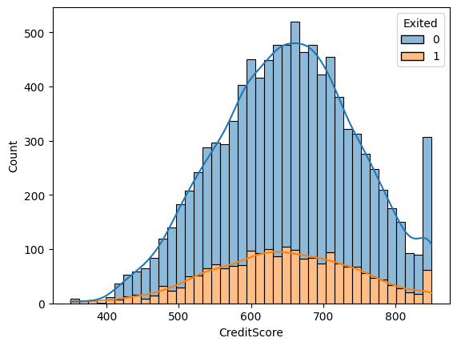

```python
sns.histplot(df, x='CreditScore', hue='Exited', multiple='stack', kde=True);
```

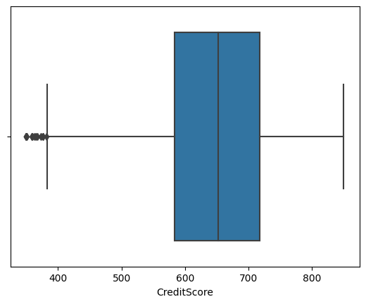

```python
sns.boxplot(x=df['CreditScore']);
```

The distribution for Credit Scores is slightly left skewed. The median is 650 with 50% ranging from 580-720. There are outliers with under 380 scores. And there is an uptick of people with 820+ scores.

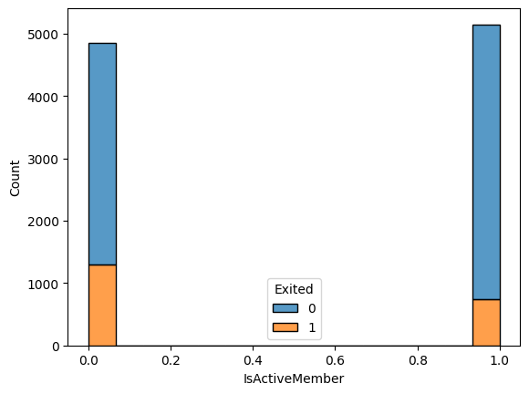

```python
sns.histplot(df, x='IsActiveMember', hue='Exited', multiple='stack');
```

```python
df['IsActiveMember'].value_counts()
```

```
1    5151
0    4849
Name: IsActiveMember, dtype: int64
```

There are 5151 active members compared to 4849 inactive. Inactives are more likely to exit.

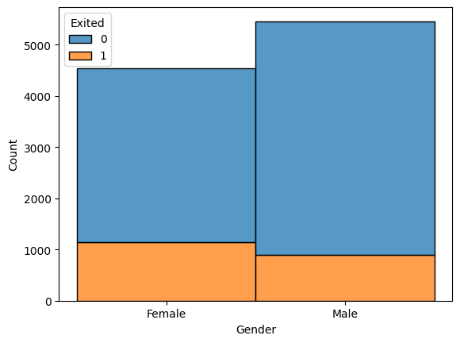

```python
sns.histplot(df, x='Gender', hue='Exited', multiple='stack');
```

```python
df['Gender'].value_counts()
```

```
Male      5457
Female    4543
Name: Gender, dtype: int64
```

There are more males than females. And males are less likely to exit.

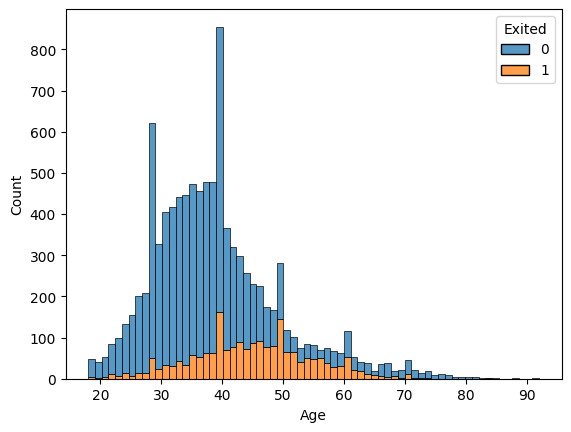

```python
sns.histplot(df, x='Age', hue='Exited', multiple='stack');
```

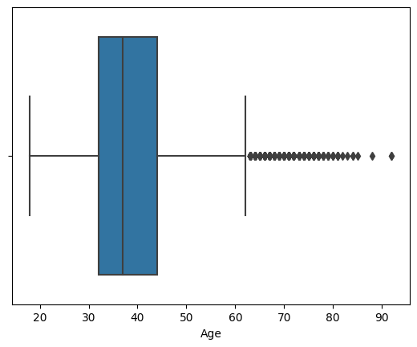

```python
sns.boxplot(x=df['Age']);
```

The distribution graph for age is right skewed. Half of people age 50 and 60 exited.

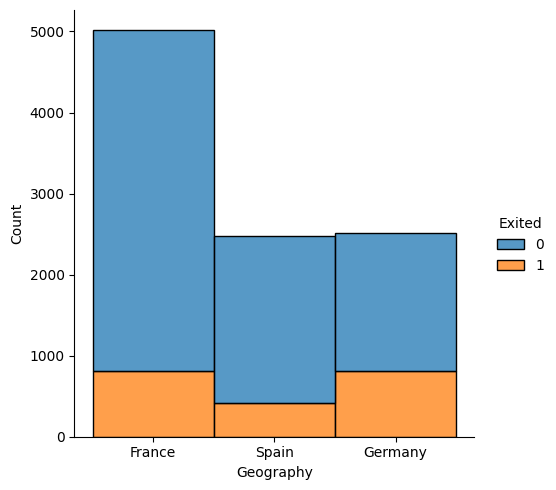

```python
sns.displot(data=df, x='Geography', hue='Exited', multiple='stack');
```

There are more customers in France than Spain and Germany. Germany has a higher percentage of exited customers.

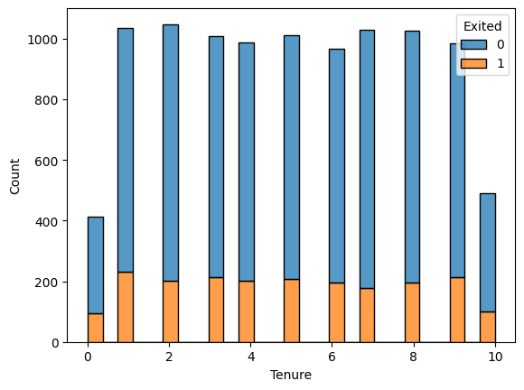

```python
sns.histplot(data=df, x='Tenure', hue='Exited', multiple='stack');
```

There doesn't seem to be a correlation between tenure and exited customers.

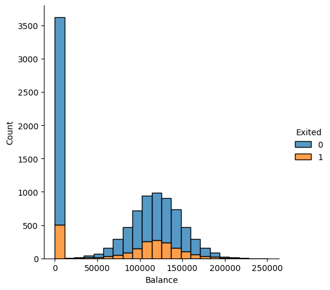

```python
sns.displot(data=df, x='Balance', hue='Exited', multiple='stack');
```

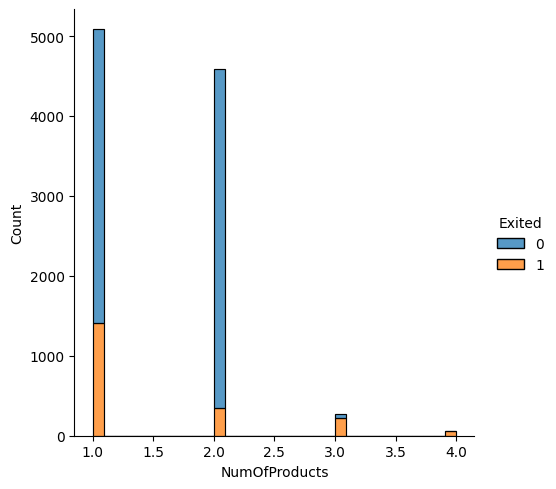

```python
sns.displot(data=df, x='NumOfProducts', hue='Exited', multiple='stack');
```

Almost all customers who bought 4 products have exited. The majority of customers who bought 3 products have exited. People who bought 1 product have higher chance of exiting than people who bought 2.

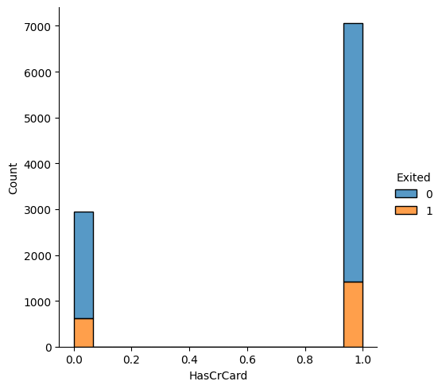

```python
sns.displot(data=df, x='HasCrCard', hue='Exited', multiple='stack');
```

There is no correlation between exited customers and credit card ownership.

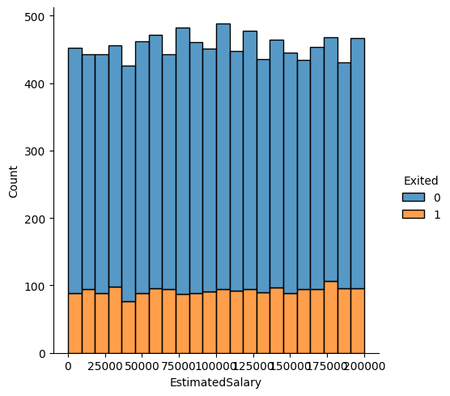

```python
sns.displot(data=df, x='EstimatedSalary', hue='Exited', multiple='stack');
```

No correlation between salary and chances of exiting.

```python
#one hot encode 'Geography' and 'Gender' columns

df = pd.get_dummies(df, columns=['Geography', 'Gender'])
```

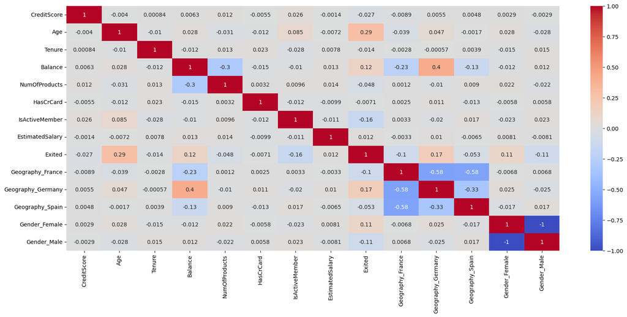

```python
plt.figure(figsize=(20, 8))
sns.heatmap(df.corr(), annot=True, cmap='coolwarm', center=0);
```

There is a correlation between balance and German accounts. There is also a correlation between a customer's age and whether or not they exited.

## Data Preprocessing

- Missing value treatment
- Feature engineering (if needed)
- Outlier detection and treatment (if needed)
- Preparing data for modeling
- Any other preprocessing steps (if needed)

```python
X = df.drop(columns=['Exited'])  # Features
y = df['Exited']  # Target

# Split the data into train (60%), validation (20%), and test (20%) sets while maintaining class balance
X_train, X_temp, y_train, y_temp = train_test_split(X, y, test_size=0.4, stratify=y, random_state=42)
X_val, X_test, y_val, y_test = train_test_split(X_temp, y_temp, test_size=0.5, stratify=y_temp, random_state=42)

# Standardize the input features
scaler = StandardScaler()
X_train = scaler.fit_transform(X_train)
X_val = scaler.transform(X_val)
X_test = scaler.transform(X_test)
```

## Model Building

### Model Evaluation Criterion

- I chose Recall to be the criterion.

### Model Building: Neural Network

```python
# Build a neural network with L1 regularization
model = Sequential()
model.add(Dense(64, activation='relu', input_dim=X_train.shape[1], kernel_regularizer=tf.keras.regularizers.l1(0.01)))
model.add(Dense(32, activation='relu'))
model.add(Dense(1, activation='sigmoid'))

# Compile the model
model.compile(loss='binary_crossentropy', metrics=['accuracy'])

# Train the model
history = model.fit(X_train, y_train, validation_data=(X_val, y_val), epochs=30, batch_size=32, verbose=1)

# Predict on both training and validation sets
y_train_pred = model.predict(X_train)
y_train_pred_binary = (y_train_pred > 0.5).astype(int)

y_val_pred = model.predict(X_val)
y_val_pred_binary = (y_val_pred > 0.5).astype(int)

# Calculate precision, recall, accuracy, and F1 score for training set
train_precision = precision_score(y_train, y_train_pred_binary)
train_recall = recall_score(y_train, y_train_pred_binary)
train_accuracy = accuracy_score(y_train, y_train_pred_binary)
train_f1 = f1_score(y_train, y_train_pred_binary)

# Calculate precision, recall, accuracy, and F1 score for validation set
val_precision = precision_score(y_val, y_val_pred_binary)
val_recall = recall_score(y_val, y_val_pred_binary)
val_accuracy = accuracy_score(y_val, y_val_pred_binary)
val_f1 = f1_score(y_val, y_val_pred_binary)

print('---')
print("Training Precision:", train_precision)
print("Training Recall:", train_recall)
print("Training Accuracy:", train_accuracy)
print("Training F1 Score:", train_f1)
print('---')
print("Validation Precision:", val_precision)
print("Validation Recall:", val_recall)
print("Validation Accuracy:", val_accuracy)
print("Validation F1 Score:", val_f1)
```

```
---
Training Precision: 0.7427122940430925
Training Recall: 0.4795417348608838
Training Accuracy: 0.8601666666666666
Training F1 Score: 0.5827946295375435
---
Validation Precision: 0.7508305647840532
Validation Recall: 0.553921568627451
Validation Accuracy: 0.8715
Validation F1 Score: 0.6375176304654443
```

Precision, Accuracy, and F1 scores are decent but I'm not too happy with Recall.

```python
# Build a neural network with L1 regularization and SGD optimizer
model = Sequential()
model.add(Dense(64, activation='relu', input_dim=X_train.shape[1], kernel_regularizer=tf.keras.regularizers.l1(0.01)))
model.add(Dense(32, activation='relu'))
model.add(Dense(1, activation='sigmoid'))

# Compile the model with SGD optimizer
sgd_optimizer = tf.keras.optimizers.SGD(learning_rate=0.01)  # You can adjust the learning rate as needed
model.compile(optimizer=sgd_optimizer, loss='binary_crossentropy', metrics=['accuracy'])

# Train the model
history = model.fit(X_train, y_train, validation_data=(X_val, y_val), epochs=30, batch_size=32, verbose=1)

# Predict on both training and validation sets
y_train_pred = model.predict(X_train)
y_train_pred_binary = (y_train_pred > 0.5).astype(int)

y_val_pred = model.predict(X_val)
y_val_pred_binary = (y_val_pred > 0.5).astype(int)

# Calculate precision, recall, accuracy, and F1 score for training set
train_precision = precision_score(y_train, y_train_pred_binary)
train_recall = recall_score(y_train, y_train_pred_binary)
train_accuracy = accuracy_score(y_train, y_train_pred_binary)
train_f1 = f1_score(y_train, y_train_pred_binary)

# Calculate precision, recall, accuracy, and F1 score for validation set
val_precision = precision_score(y_val, y_val_pred_binary)
val_recall = recall_score(y_val, y_val_pred_binary)
val_accuracy = accuracy_score(y_val, y_val_pred_binary)
val_f1 = f1_score(y_val, y_val_pred_binary)

print('---')
print("Training Precision:", train_precision)
print("Training Recall:", train_recall)
print("Training Accuracy:", train_accuracy)
print("Training F1 Score:", train_f1)
print('---')
print("Validation Precision:", val_precision)
print("Validation Recall:", val_recall)
print("Validation Accuracy:", val_accuracy)
print("Validation F1 Score:", val_f1)
```

```
---
Training Precision: 0.8234086242299795
Training Recall: 0.3281505728314239
Training Accuracy: 0.8488333333333333
Training F1 Score: 0.4692802808660035
---
Validation Precision: 0.8360655737704918
Validation Recall: 0.375
Validation Accuracy: 0.8575
Validation F1 Score: 0.5177664974619289
```

Precision and Accuracy are fine but Recall and F1 are bad.

### Model Building: Neural Network model with Adam Optimizer

```python
# Build a neural network with Adam optimizer
model = Sequential()
model.add(Dense(64, activation='relu', input_dim=X_train.shape[1], kernel_regularizer=tf.keras.regularizers.l1(0.01)))
model.add(Dense(32, activation='relu'))
model.add(Dense(1, activation='sigmoid'))

# Compile the model with the Adam optimizer
model.compile(optimizer=tf.keras.optimizers.Adam(learning_rate=0.001), loss='binary_crossentropy', metrics=['accuracy'])

# Train the model
history = model.fit(X_train, y_train, validation_data=(X_val, y_val), epochs=30, batch_size=32, verbose=1)

# Predict on both training and validation sets
y_train_pred = model.predict(X_train)
y_train_pred_binary = (y_train_pred > 0.5).astype(int)

y_val_pred = model.predict(X_val)
y_val_pred_binary = (y_val_pred > 0.5).astype(int)

# Calculate precision, recall, accuracy, and F1 score for training set
train_precision = precision_score(y_train, y_train_pred_binary)
train_recall = recall_score(y_train, y_train_pred_binary)
train_accuracy = accuracy_score(y_train, y_train_pred_binary)
train_f1 = f1_score(y_train, y_train_pred_binary)

# Calculate precision, recall, accuracy, and F1 score for validation set
val_precision = precision_score(y_val, y_val_pred_binary)
val_recall = recall_score(y_val, y_val_pred_binary)
val_accuracy = accuracy_score(y_val, y_val_pred_binary)
val_f1 = f1_score(y_val, y_val_pred_binary)

print('---')
print("Training Precision:", train_precision)
print("Training Recall:", train_recall)
print("Training Accuracy:", train_accuracy)
print("Training F1 Score:", train_f1)
print('---')
print("Validation Precision:", val_precision)
print("Validation Recall:", val_recall)
print("Validation Accuracy:", val_accuracy)
print("Validation F1 Score:", val_f1)
```

```
---
Training Precision: 0.7419354838709677
Training Recall: 0.4705400981996727
Training Accuracy: 0.8588333333333333
Training F1 Score: 0.5758637956935403
---
Validation Precision: 0.7632508833922261
Validation Recall: 0.5294117647058824
Validation Accuracy: 0.8705
Validation F1 Score: 0.6251808972503619
```

Again, recall is bad compared to the other scores.

### Model Improvement: Neural Network model with Dropout

```python
# Build a neural network with L1 regularization, Adam optimizer, and dropout
model = Sequential()
model.add(Dense(64, activation='relu', input_dim=X_train.shape[1], kernel_regularizer=tf.keras.regularizers.l1(0.01)))
model.add(Dropout(0.5))  # Add dropout layer with a dropout rate of 0.5
model.add(Dense(32, activation='relu'))
model.add(Dropout(0.5))  # Add another dropout layer
model.add(Dense(1, activation='sigmoid'))

# Compile the model with the Adam optimizer
model.compile(optimizer=tf.keras.optimizers.Adam(learning_rate=0.001), loss='binary_crossentropy', metrics=['accuracy'])

# Train the model
history = model.fit(X_train, y_train, validation_data=(X_val, y_val), epochs=30, batch_size=32, verbose=1)

# Predict on both training and validation sets
y_train_pred = model.predict(X_train)
y_train_pred_binary = (y_train_pred > 0.5).astype(int)

y_val_pred = model.predict(X_val)
y_val_pred_binary = (y_val_pred > 0.5).astype(int)

# Calculate precision, recall, accuracy, and F1 score for training set
train_precision = precision_score(y_train, y_train_pred_binary)
train_recall = recall_score(y_train, y_train_pred_binary)
train_accuracy = accuracy_score(y_train, y_train_pred_binary)
train_f1 = f1_score(y_train, y_train_pred_binary)

# Calculate precision, recall, accuracy, and F1 score for validation set
val_precision = precision_score(y_val, y_val_pred_binary)
val_recall = recall_score(y_val, y_val_pred_binary)
val_accuracy = accuracy_score(y_val, y_val_pred_binary)
val_f1 = f1_score(y_val, y_val_pred_binary)

print('---')
print("Training Precision:", train_precision)
print("Training Recall:", train_recall)
print("Training Accuracy:", train_accuracy)
print("Training F1 Score:", train_f1)
print('---')
print("Validation Precision:", val_precision)
print("Validation Recall:", val_recall)
print("Validation Accuracy:", val_accuracy)
print("Validation F1 Score:", val_f1)
```

```
---
Training Precision: 0.7554858934169278
Training Recall: 0.3944353518821604
Training Accuracy: 0.8506666666666667
Training F1 Score: 0.5182795698924731
---
Validation Precision: 0.7967479674796748
Validation Recall: 0.4803921568627451
Validation Accuracy: 0.869
Validation F1 Score: 0.599388379204893
```

Bad recall and F1.

### Model Improvement: Neural Network model with Hyperparameter tuning

```python
# Define hyperparameters to search over
learning_rates = [0.001, 0.01, 0.1]
dropout_rates = [0.3, 0.5, 0.7]
epochs = [20, 30, 40]

best_val_f1 = 0
best_params = {}

for learning_rate in learning_rates:
    for dropout_rate in dropout_rates:
        # Build the model with current hyperparameters
        model = Sequential()
        model.add(Dense(64, activation='relu', input_dim=X_train.shape[1], kernel_regularizer=tf.keras.regularizers.l1(0.01)))
        model.add(Dropout(dropout_rate))
        model.add(Dense(32, activation='relu'))
        model.add(Dropout(dropout_rate))
        model.add(Dense(1, activation='sigmoid'))
        model.compile(optimizer=tf.keras.optimizers.Adam(learning_rate=learning_rate), loss='binary_crossentropy', metrics=['accuracy'])

        # Train the model
        history = model.fit(X_train, y_train, validation_data=(X_val, y_val), epochs=30, batch_size=32, verbose=0)

        # Predict on validation set
        y_val_pred = model.predict(X_val)
        y_val_pred_binary = (y_val_pred > 0.5).astype(int)

        # Calculate F1 score for validation set
        val_f1 = f1_score(y_val, y_val_pred_binary)

        # Check if this combination is the best
        if val_f1 > best_val_f1:
            best_val_f1 = val_f1
            best_params = {'learning_rate': learning_rate, 'dropout_rate': dropout_rate}

# Build the final model with the best hyperparameters
final_model = Sequential()
final_model.add(Dense(64, activation='relu', input_dim=X_train.shape[1], kernel_regularizer=tf.keras.regularizers.l1(0.01)))
final_model.add(Dropout(best_params['dropout_rate']))
final_model.add(Dense(32, activation='relu'))
final_model.add(Dropout(best_params['dropout_rate']))
final_model.add(Dense(1, activation='sigmoid'))
final_model.compile(optimizer=tf.keras.optimizers.Adam(learning_rate=best_params['learning_rate']), loss='binary_crossentropy', metrics=['accuracy'])

# Train the final model
history = final_model.fit(X_train, y_train, validation_data=(X_val, y_val), epochs=30, batch_size=32, verbose=1)

# Predict on both training and validation sets
y_train_pred = final_model.predict(X_train)
y_train_pred_binary = (y_train_pred > 0.5).astype(int)

y_val_pred = final_model.predict(X_val)
y_val_pred_binary = (y_val_pred > 0.5).astype(int)

# Calculate precision, recall, accuracy, and F1 score for training set
train_precision = precision_score(y_train, y_train_pred_binary)
train_recall = recall_score(y_train, y_train_pred_binary)
train_accuracy = accuracy_score(y_train, y_train_pred_binary)
train_f1 = f1_score(y_train, y_train_pred_binary)

# Calculate precision, recall, accuracy, and F1 score for validation set
val_precision = precision_score(y_val, y_val_pred_binary)
val_recall = recall_score(y_val, y_val_pred_binary)
val_accuracy = accuracy_score(y_val, y_val_pred_binary)
val_f1 = f1_score(y_val, y_val_pred_binary)

print('---')
print("Best Hyperparameters:", best_params)
print('---')
print("Training Precision:", train_precision)
print("Training Recall:", train_recall)
print("Training Accuracy:", train_accuracy)
print("Training F1 Score:", train_f1)
print('---')
print("Validation Precision:", val_precision)
print("Validation Recall:", val_recall)
print("Validation Accuracy:", val_accuracy)
print("Validation F1 Score:", val_f1)
```

```
---
Best Hyperparameters: {'learning_rate': 0.001, 'dropout_rate': 0.5}
---
Training Precision: 0.8441558441558441
Training Recall: 0.3191489361702128
Training Accuracy: 0.8493333333333334
Training F1 Score: 0.4631828978622329
---
Validation Precision: 0.8322981366459627
Validation Recall: 0.3284313725490196
Validation Accuracy: 0.8495
Validation F1 Score: 0.47100175746924433
```

Very bad recall.

### Model Improvement: Neural Network model with balanced data

```python
# Oversample the training data
oversampler = RandomOverSampler(sampling_strategy='auto', random_state=2)
X_train_resampled, y_train_resampled = oversampler.fit_resample(X_train, y_train)

# Build a neural network with L1 regularization (no dropout)
def build_model(learning_rate=0.001):
    model = Sequential()
    model.add(Dense(64, activation='relu', input_dim=X_train.shape[1], kernel_regularizer=tf.keras.regularizers.l1(0.01)))
    model.add(Dense(32, activation='relu'))
    model.add(Dense(1, activation='sigmoid'))
    model.compile(optimizer=tf.keras.optimizers.Adam(learning_rate=learning_rate), loss='binary_crossentropy', metrics=['accuracy'])
    return model

# Create and compile the model
model = build_model(learning_rate=0.001)

# Train the model on the oversampled data
history = model.fit(X_train_resampled, y_train_resampled, epochs=30, batch_size=32, verbose=1)

# Predict on the training set
y_train_pred = model.predict(X_train_resampled)
y_train_pred_binary = (y_train_pred > 0.5).astype(int)

# Calculate precision, recall, accuracy, and F1 score for training set
train_precision = precision_score(y_train_resampled, y_train_pred_binary)
train_recall = recall_score(y_train_resampled, y_train_pred_binary)
train_accuracy = accuracy_score(y_train_resampled, y_train_pred_binary)
train_f1 = f1_score(y_train_resampled, y_train_pred_binary)

print("Training Precision:", train_precision)
print("Training Recall:", train_recall)
print("Training Accuracy:", train_accuracy)
print("Training F1 Score:", train_f1)

# Predict on the validation set
y_val_pred = model.predict(X_val)
y_val_pred_binary = (y_val_pred > 0.5).astype(int)

# Calculate precision, recall, accuracy, and F1 score for validation set
val_precision = precision_score(y_val, y_val_pred_binary)
val_recall = recall_score(y_val, y_val_pred_binary)
val_accuracy = accuracy_score(y_val, y_val_pred_binary)
val_f1 = f1_score(y_val, y_val_pred_binary)

print("Validation Precision:", val_precision)
print("Validation Recall:", val_recall)
print("Validation Accuracy:", val_accuracy)
print("Validation F1 Score:", val_f1)
```

```
Training Precision: 0.8151318833873207
Training Recall: 0.7373377982419422
Training Accuracy: 0.7850565089995815
Training F1 Score: 0.7742857142857142
Validation Precision: 0.5194585448392555
Validation Recall: 0.7524509803921569
Validation Accuracy: 0.8075
Validation F1 Score: 0.6146146146146146
```

This has the best Recall out of all the models so far.

```python
# Oversample the training data using SMOTE
smote = SMOTE(sampling_strategy='auto', random_state=2)
X_train_smote, y_train_smote = smote.fit_resample(X_train, y_train)

# Build a neural network with L1 regularization (no dropout)
def build_model(learning_rate=0.001):
    model = Sequential()
    model.add(Dense(64, activation='relu', input_dim=X_train.shape[1], kernel_regularizer=tf.keras.regularizers.l1(0.01)))
    model.add(Dense(32, activation='relu'))
    model.add(Dense(1, activation='sigmoid'))
    model.compile(optimizer=tf.keras.optimizers.Adam(learning_rate=learning_rate), loss='binary_crossentropy', metrics=['accuracy'])
    return model

# Create and compile the model
model = build_model(learning_rate=0.001)

# Train the model on the oversampled data
history = model.fit(X_train_smote, y_train_smote, epochs=30, batch_size=32, verbose=1)

# Predict on the training set
y_train_pred = model.predict(X_train_smote)
y_train_pred_binary = (y_train_pred > 0.5).astype(int)

# Calculate precision, recall, accuracy, and F1 score for training set
train_precision = precision_score(y_train_smote, y_train_pred_binary)
train_recall = recall_score(y_train_smote, y_train_pred_binary)
train_accuracy = accuracy_score(y_train_smote, y_train_pred_binary)
train_f1 = f1_score(y_train_smote, y_train_pred_binary)

print("Training Precision:", train_precision)
print("Training Recall:", train_recall)
print("Training Accuracy:", train_accuracy)
print("Training F1 Score:", train_f1)

# Predict on the validation set
y_val_pred = model.predict(X_val)
y_val_pred_binary = (y_val_pred > 0.5).astype(int)

# Calculate precision, recall, accuracy, and F1 score for validation set
val_precision = precision_score(y_val, y_val_pred_binary)
val_recall = recall_score(y_val, y_val_pred_binary)
val_accuracy = accuracy_score(y_val, y_val_pred_binary)
val_f1 = f1_score(y_val, y_val_pred_binary)

print("Validation Precision:", val_precision)
print("Validation Recall:", val_recall)
print("Validation Accuracy:", val_accuracy)
print("Validation F1 Score:", val_f1)
```

```
Training Precision: 0.810162780466344
Training Recall: 0.7708246128087066
Training Accuracy: 0.7951025533696107
Training F1 Score: 0.7900042900042901
Validation Precision: 0.5023474178403756
Validation Recall: 0.7867647058823529
Validation Accuracy: 0.7975
Validation F1 Score: 0.6131805157593123
```

## Final Model

```python
# Oversample the training data using SMOTE
smote = SMOTE(sampling_strategy='auto', random_state=2)
X_train_smote, y_train_smote = smote.fit_resample(X_train, y_train)

# Build a neural network with L1 regularization (no dropout)
def build_model(learning_rate=0.001):
    model = Sequential()
    model.add(Dense(64, activation='relu', input_dim=X_train.shape[1], kernel_regularizer=tf.keras.regularizers.l1(0.01)))
    model.add(Dense(32, activation='relu'))
    model.add(Dense(1, activation='sigmoid'))
    model.compile(optimizer=tf.keras.optimizers.Adam(learning_rate=learning_rate), loss='binary_crossentropy', metrics=['accuracy'])
    return model

# Create and compile the model
model = build_model(learning_rate=0.001)

# Train the model on the oversampled data
history = model.fit(X_train_smote, y_train_smote, epochs=30, batch_size=32, verbose=1)

# Predict on the test set
y_test_pred = model.predict(X_test)
y_test_pred_binary = (y_test_pred > 0.5).astype(int)

# Calculate precision, recall, accuracy, and F1 score for test set
test_precision = precision_score(y_test, y_test_pred_binary)
test_recall = recall_score(y_test, y_test_pred_binary)
test_accuracy = accuracy_score(y_test, y_test_pred_binary)
test_f1 = f1_score(y_test, y_test_pred_binary)

print("Test Precision:", test_precision)
print("Test Recall:", test_recall)
print("Test Accuracy:", test_accuracy)
print("Test F1 Score:", test_f1)
```

```
Test Precision: 0.4106699751861042
Test Recall: 0.8132678132678133
Test Accuracy: 0.7245
Test F1 Score: 0.5457543281121187
```

I chose the model with the oversampled data using SMOTE because it had the highest Recall score on the validation set.

When applied to testing set, Recall scored at 81%

## Actionable Insights and Recommendations

**What recommedations would you suggest to the bank?**

I have also noticed a pattern in customers who have higher potential of exiting:

- Inactive members are more likely to exit
- Females are more likely to exit
- People are near 50 and 60 years old are more likely to exit.
- People in Germany are more likely to exit.
- People who bought 3 and 4 products are most likely to exit. People who bought 2 are least likely to exit.

I recommend the bank use this information to build a retention strategy.

```python
%%shell
jupyter nbconvert /content/drive/MyDrive/Nguyen_Le_INN_Learner_Notebook_Full_code_version.ipynb --to html
```

```
[NbConvertApp] Converting notebook /content/drive/MyDrive/Nguyen_Le_INN_Learner_Notebook_Full_code_version.ipynb to html
[NbConvertApp] Writing 1267076 bytes to /content/drive/MyDrive/Nguyen_Le_INN_Learner_Notebook_Full_code_version.html
```